# Job Clustering

```python
import pandas as pd
import numpy as np
from gensim.models import Word2Vec
from collections import Counter
from tqdm import tqdm

from sklearn.cluster import KMeans
from sklearn import metrics
from sklearn.decomposition import PCA
from sklearn.metrics import pairwise_distances
from scipy.spatial import ConvexHull
from sklearn.utils import shuffle
from sklearn.preprocessing import MinMaxScaler

import scipy.cluster.hierarchy as shc
import scipy.spatial
from sklearn.cluster import AgglomerativeClustering
from scipy.cluster.hierarchy import cophenet, fcluster

import plotly.graph_objects as go
from plotly.subplots import make_subplots
import seaborn as sns
from matplotlib import style, pyplot as plt
style.use("ggplot")
```

```python
df = pd.read_csv("verbs.csv", sep=";")
```

### INPUTS

```python
# Number of categories to cluster key words by
n_word_cats = 5

# Number of top title categories to create variables for
n_top_titles = 5

# K number of clusters
n_clusters = 4
```

## 1. KMeans Clustering (Task)

#### Create Word2Vec model

We will be using Word2vec library. Word2Vec is one of the popular methods in language modeling and feature learning techniques in natural language processing (NLP). This method is used to create word embeddings in machine learning whenever we need vector representation of data.

A word2vec model is a simple neural network model with a single hidden layer. The task of this model is to predict the nearby words for each and every word in a sentence.

```python
words = [list(i.split()) for i in df.Task]
model = Word2Vec(words, min_count=1, seed=0)
```

#### Vectorise task list

```python
X = []
for key_words in words:
    job_vec, count = [], 0
    for word in key_words:
        if count == 0: job_vec = model[word]
        else: job_vec = np.add(job_vec, model[word])
        count += 1
    X.append(job_vec)
```

#### Plot silhouette score and inertia to find optimal K

The K value will define the optimal number of clusters of words we want to have, which will then be used to classify jobs.

```python
distortions, silhouette, n = [], [], 9

for i in range(2, n):
    km = KMeans(n_clusters=i, init='k-means++')
    km.fit(X)
    distortions.append(km.inertia_)
    silhouette.append(metrics.silhouette_score(X, km.labels_))
```

```python
fig = make_subplots(specs=[[{"secondary_y": True}]])

fig.add_trace(
    go.Scatter(x=list(range(2,n)), y=distortions, name="Inertia Score"), secondary_y=False)
fig.add_trace(
    go.Scatter(x=list(range(2,n)), y=silhouette, name="Silhouette Score"), secondary_y=True)

fig.update_xaxes(title_text='Number of Clusters')
fig.update_yaxes(title_text="Inertia Score",secondary_y=False)
fig.update_yaxes(title_text="Silhouette Score",secondary_y=True)
fig.layout.template = 'ggplot2'
fig.show()
```

[interactive chart not shown]

#### Fit clusters

```python
km = KMeans(
    n_clusters=n_clusters, init='k-means++',
    n_init=10, max_iter=300,
    tol=1e-04, random_state=25
)

y_km_sent = km.fit_predict(X)
```

## 2. Hierarchical Clustering (Categorical)

#### Vectorise key words in job tasks

```python
X = model[model.wv.vocab]
vocab = list(model.wv.vocab.keys())
```

#### Cluster key words to find higher level categorisation

```python
km = KMeans(n_clusters=n_word_cats, init='k-means++', random_state=0)
y_km_vocab = km.fit_predict(X)
```

```python
vocab = pd.DataFrame({'Word':vocab,'Cluster':y_km_vocab})
vocab.head()
```

|  | Word | Cluster |
| --- | --- | --- |
| 0 | Develop | 1 |
| 1 | Prepare | 1 |
| 2 | Review | 1 |
| 3 | Establish | 1 |
| 4 | Analyze | 1 |

```python
fig = go.Figure(data=[go.Pie(values=list(Counter(y_km_vocab).values()),
                             labels=list(Counter(y_km_vocab).keys()),
                             textinfo='percent',
                             textfont=dict(color="white"),
                             textposition='inside')])
fig.layout.template = 'ggplot2'
fig.show()
```

[interactive chart not shown]

#### Function to create dummy variable or counts if job tasks has key word in cluster

```python
def dummycount(dummy_type, n_word_cats=n_word_cats, title=df.Title, vocab=vocab):
    cols = ['title']+list(range(n_word_cats))
    d = pd.DataFrame(np.zeros((len(title), n_word_cats+1)).astype(int), columns=cols)
    d['title'] = title

    for ind, job in tqdm(enumerate(d.title)):
        for word in words[ind]:
            cluster = vocab.Cluster[np.where(word == vocab.Word)[0][0]]

            if dummy_type == 'dummy':
                d.iloc[ind,cluster+1] = 1
            elif dummy_type == 'count':
                d.iloc[ind,cluster+1] += 1

    return d
```

```python
d = dummycount('dummy')
d[:5]
```

```
974it [00:14, 65.15it/s]
```

|  | title | 0 | 1 | 2 | 3 | 4 |
| --- | --- | --- | --- | --- | --- | --- |
| 0 | Accountants | 1 | 1 | 0 | 1 | 1 |
| 1 | Actors | 1 | 1 | 1 | 1 | 1 |
| 2 | Actuaries | 0 | 1 | 1 | 1 | 1 |
| 3 | Acupuncturists | 1 | 1 | 1 | 1 | 1 |
| 4 | Acute Care Nurses | 0 | 1 | 1 | 1 | 1 |

#### Get most frequent job title key words

```python
title_words = [list(i.split()) for i in list(set(df.Title))]
flat_tw = [item for sublist in title_words for item in sublist if item.islower() == False]
labels, values = zip(*Counter(flat_tw).items())
values, labels = zip(*sorted(zip(values, labels),reverse=True))
```

```python
top_labels = labels[:n_top_titles]
top_labels
```

```
('Technicians', 'Workers', 'Managers', 'Machine', 'Teachers,')
```

```python
cat_col = []
for tw in df.Title:
    tw = tw.split()
    intersect = list(set(tw) & set(top_labels))
    if 'Executive' in tw:
        cat_col.append('Managers')
    elif len(intersect) > 0:
        cat_col.append(intersect[0])
    else:
        cat_col.append('Other')

assert len(cat_col) == len(d)
cat_col[:5]
```

```
['Other', 'Other', 'Other', 'Other', 'Other']
```

```python
d = d.merge(pd.get_dummies(pd.Series(cat_col)), left_index=True, right_index=True).set_index('title')
d.head()
```

| title | 0 | 1 | 2 | 3 | 4 | Machine | Managers | Other | Teachers, | Technicians | Workers |
| --- | --- | --- | --- | --- | --- | --- | --- | --- | --- | --- | --- |
| Accountants | 1 | 1 | 0 | 1 | 1 | 0 | 0 | 1 | 0 | 0 | 0 |
| Actors | 1 | 1 | 1 | 1 | 1 | 0 | 0 | 1 | 0 | 0 | 0 |
| Actuaries | 0 | 1 | 1 | 1 | 1 | 0 | 0 | 1 | 0 | 0 | 0 |
| Acupuncturists | 1 | 1 | 1 | 1 | 1 | 0 | 0 | 1 | 0 | 0 | 0 |
| Acute Care Nurses | 0 | 1 | 1 | 1 | 1 | 0 | 0 | 1 | 0 | 0 | 0 |

#### Hierarchical clustering

```python
Z = shc.linkage(d, 'ward')
c, coph_dists = shc.cophenet(Z, scipy.spatial.distance.pdist(d))
round(c,3)
```

```
0.83
```

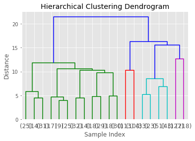

```python
plt.title('Hierarchical Clustering Dendrogram')
plt.xlabel('Sample Index')
plt.ylabel('Distance')
dend = shc.dendrogram(Z, truncate_mode='lastp',p=20)
plt.show()
```

```python
h = fcluster(Z,n_clusters,criterion='maxclust')
```

## 3. KMeans Clustering (Numerical)

#### Get word category counts

```python
dk = dummycount('count')
dk[:5]
```

```
974it [00:15, 63.36it/s]
```

|  | title | 0 | 1 | 2 | 3 | 4 |
| --- | --- | --- | --- | --- | --- | --- |
| 0 | Accountants | 2 | 10 | 0 | 4 | 1 |
| 1 | Actors | 3 | 8 | 3 | 3 | 2 |
| 2 | Actuaries | 0 | 7 | 1 | 5 | 2 |
| 3 | Acupuncturists | 1 | 7 | 2 | 4 | 4 |
| 4 | Acute Care Nurses | 0 | 16 | 1 | 7 | 3 |

#### Fit clusters

```python
X = dk.drop(columns=['title'])

km_cluster = KMeans(
    n_clusters=n_clusters, init='k-means++',
    n_init=10, max_iter=300,
    tol=1e-04, random_state=0
)

y_km_word = km_cluster.fit_predict(X)
```

```python
print('Silhouette score: ',round(metrics.silhouette_score(X, km_cluster.labels_),4))
```

```
Silhouette score:  0.2872
```

## 4. Clustering Methods Performance Comparison

```python
df = dk.merge(pd.get_dummies(pd.Series(cat_col)), left_index=True, right_index=True).set_index('title')
df['tasks'], df['kmeans_sent'], df['hierarchical'], df['kmeans_word'] = words, y_km_sent, h-1, y_km_word
```

```python
df.head()
```

| title | 0 | 1 | 2 | 3 | 4 | Machine | Managers | Other | Teachers, | Technicians | Workers | tasks | kmeans_sent | hierarchical | kmeans_word |
| --- | --- | --- | --- | --- | --- | --- | --- | --- | --- | --- | --- | --- | --- | --- | --- |
| Accountants | 2 | 10 | 0 | 4 | 1 | 0 | 0 | 1 | 0 | 0 | 0 | [Develop, Prepare, Review, Prepare, Establish,... | 1 | 3 | 0 |
| Actors | 3 | 8 | 3 | 3 | 2 | 0 | 0 | 1 | 0 | 0 | 0 | [Collaborate, Portray, Work, Perform, Study, L... | 3 | 3 | 0 |
| Actuaries | 0 | 7 | 1 | 5 | 2 | 0 | 0 | 1 | 0 | 0 | 0 | [Ascertain, Design, Determine, Provide, Analyz... | 3 | 1 | 1 |
| Acupuncturists | 1 | 7 | 2 | 4 | 4 | 0 | 0 | 1 | 0 | 0 | 0 | [Insert, Maintain, Adhere, Identify, Maintain,... | 1 | 3 | 1 |
| Acute Care Nurses | 0 | 16 | 1 | 7 | 3 | 0 | 0 | 1 | 0 | 0 | 0 | [Perform, Manage, Document, Diagnose, Administ... | 2 | 1 | 2 |

### Automation definition from McKinsey Report

The following definitions are from the "Job Lost, Job Gained McKinsey report".

Jobs who are the mostly likely to be automated have the following characteristics:

- Less personal interactions
- Predictable or unpredictable physical activities
- Repetitive Tasks (such as collecting data);

Jobs who are the least likely to be automated have the following characteristics:

- Need logical reasoning,
- Social skills,
- Or creative skills
- Management-related

### 4.1 Word Clusters Analysis

#### Examine word categories for labelling dataframe

```python
word_cats = {}
for i in range(n_word_cats):
    word_cats[i] = list(Counter(vocab[vocab['Cluster']==i]['Word']).keys())[:5]

word_cats
```

```
{0: ['Appraise', 'Survey', 'Learn', 'Sing', 'Manipulate'],
 1: ['Develop', 'Prepare', 'Review', 'Establish', 'Analyze'],
 2: ['Portray', 'Tell', 'Introduce', 'Ascertain', 'Adhere'],
 3: ['Report', 'Maintain', 'Compute', 'Provide', 'Perform'],
 4: ['Represent', 'Promote', 'Dress', 'Testify', 'Treat']}
```

By looking at our five different word clusters above, we observe that those clusters group words with different meaning:

- The 'Represent' cluster contains in general non-physical tasks which require personal interaction and logical reasoning (usually performed by a manager) such as 'represent' , 'promote', 'prescribe' , 'Hire', 'Oversee' ;
- Overall, the 'Report' category lists repetitive tasks such as 'Report', 'Examine' , 'Provide','Maintain','Compute' and so on;
- The 'Develop' category has tasks which require logical reasoning, personal interactions and even creative skills ('Advise','Develop','Write','Negotiate', 'Manage','Explain');
- Last, as regard to the 'Portray' and 'Appraise' clusters, we observe that they represent general tasks which in overall don't fall into a specific category ;

We used the following criterias to define the categories above: Physical, Repetitiveness , Social interactions and Need of logical reasoning. Using the definition and the criterias from the McKinsey report in the previous section, jobs which are least likely to be automated perform tasks which require social interaction or logical reasoning.

The clusters of interest that we will use to define automation are 'Represent', 'Report' and 'Develop'.

```python
#Represent 4: Managerial Tasks
#Report 3: Repetitive Tasks
#Develop 1: Logical Reasoning Tasks
#Portray 2 and Appraise 0 : undefined
```

### 4.2 Automation Percentage

```python
auto = pd.read_excel('O_NET Task Statements Automated.xlsx')
auto = auto[['Title', 'Automated']]
auto.head()
```

|  | Title | Automated |
| --- | --- | --- |
| 0 | Chief Executives | 0 |
| 1 | Chief Executives | 0 |
| 2 | Chief Executives | 0 |
| 3 | Chief Executives | 0 |
| 4 | Chief Executives | 0 |

```python
auto = auto.groupby('Title').first()
```

```python
auto.head()
```

| Title | Automated |
| --- | --- |
| Accountants | 1 |
| Actors | 0 |
| Actuaries | 0 |
| Acupuncturists | 0 |
| Acute Care Nurses | 0 |

```python
Counter(auto.Automated)
```

```
Counter({1: 435, 0: 539})
```

```python
df = df.merge(auto, left_index=True, right_index=True)
df[:2]
```

| title | 0 | 1 | 2 | 3 | 4 | Machine | Managers | Other | Teachers, | Technicians | Workers | tasks | kmeans_sent | hierarchical | kmeans_word | Automated |
| --- | --- | --- | --- | --- | --- | --- | --- | --- | --- | --- | --- | --- | --- | --- | --- | --- |
| Accountants | 2 | 10 | 0 | 4 | 1 | 0 | 0 | 1 | 0 | 0 | 0 | [Develop, Prepare, Review, Prepare, Establish,... | 1 | 3 | 0 | 1 |
| Actors | 3 | 8 | 3 | 3 | 2 | 0 | 0 | 1 | 0 | 0 | 0 | [Collaborate, Portray, Work, Perform, Study, L... | 3 | 3 | 0 | 0 |

```python
for model in ['kmeans_sent','hierarchical','kmeans_word']:
    print(model)
    print('------------------')

    for i in range(n_clusters):
        auto = Counter(df[df[model]==i].Automated)
        print('Cluster '+str(i)+': ', round(auto[1]/(auto[1]+auto[0]),3))

    print('\n')
```

```
kmeans_sent
------------------
Cluster 0:  0.421
Cluster 1:  0.486
Cluster 2:  0.366
Cluster 3:  0.514


hierarchical
------------------
Cluster 0:  0.416
Cluster 1:  0.364
Cluster 2:  0.393
Cluster 3:  0.545


kmeans_word
------------------
Cluster 0:  0.307
Cluster 1:  0.671
Cluster 2:  0.093
Cluster 3:  0.76
```

## 5. Distribution of Word Cluster for each Job Class

```python
df_word_job = df.reset_index()
df_word_job = df_word_job[['title',0,1,2,3,4,'kmeans_word']]
df_word_job = df_word_job.rename(columns = {0:'Cluster_0', 1: 'Cluster_1', 2: 'Cluster_2', 3: 'Cluster_3', 4: 'Cluster_4' })
df_word_job.head()
```

|  | title | Cluster_0 | Cluster_1 | Cluster_2 | Cluster_3 | Cluster_4 | kmeans_word |
| --- | --- | --- | --- | --- | --- | --- | --- |
| 0 | Accountants | 2 | 10 | 0 | 4 | 1 | 0 |
| 1 | Actors | 3 | 8 | 3 | 3 | 2 | 0 |
| 2 | Actuaries | 0 | 7 | 1 | 5 | 2 | 1 |
| 3 | Acupuncturists | 1 | 7 | 2 | 4 | 4 | 1 |
| 4 | Acute Care Nurses | 0 | 16 | 1 | 7 | 3 | 2 |

```python
def size_class(df, job_clusters):
    dic = {}
    for x in range(job_clusters):
        value = len(df[df['kmeans_word'] == x])
        if value not in dic:
            dic[x] = value
    return dic

size_class(df_word_job, n_clusters)
```

```
{0: 309, 1: 246, 2: 215, 3: 204}
```

```python
# include lists below in function for scalability:
lst_clusters = ['Cluster_0', "Cluster_1", "Cluster_2", "Cluster_3", "Cluster_4"]
lst_ratios = ['Cluster_0_ratio', "Cluster_1_ratio", "Cluster_2_ratio", "Cluster_3_ratio", "Cluster_4_ratio"]

def ratio(df, list_cluster, lst_ratios):
    for x in range(len(list_cluster)):
        df[lst_ratios[x]] = df[list_cluster[x]] / (df["Cluster_0"] + df["Cluster_1"] + df["Cluster_2"] + df["Cluster_3"] + df["Cluster_4"])

    return df

df_word_job = ratio(df_word_job, lst_clusters, lst_ratios)
df_word_job.head()
```

|  | title | Cluster_0 | Cluster_1 | Cluster_2 | Cluster_3 | Cluster_4 | kmeans_word | Cluster_0_ratio | Cluster_1_ratio | Cluster_2_ratio | Cluster_3_ratio | Cluster_4_ratio |
| --- | --- | --- | --- | --- | --- | --- | --- | --- | --- | --- | --- | --- |
| 0 | Accountants | 2 | 10 | 0 | 4 | 1 | 0 | 0.117647 | 0.588235 | 0.000000 | 0.235294 | 0.058824 |
| 1 | Actors | 3 | 8 | 3 | 3 | 2 | 0 | 0.157895 | 0.421053 | 0.157895 | 0.157895 | 0.105263 |
| 2 | Actuaries | 0 | 7 | 1 | 5 | 2 | 1 | 0.000000 | 0.466667 | 0.066667 | 0.333333 | 0.133333 |
| 3 | Acupuncturists | 1 | 7 | 2 | 4 | 4 | 1 | 0.055556 | 0.388889 | 0.111111 | 0.222222 | 0.222222 |
| 4 | Acute Care Nurses | 0 | 16 | 1 | 7 | 3 | 2 | 0.000000 | 0.592593 | 0.037037 | 0.259259 | 0.111111 |

```python
lst_classes = list(sorted(df_word_job['kmeans_word'].unique()))

def cluster_ratio(df, lst_ratios=lst_ratios):
    return [df[x].mean() for x in lst_ratios]

class_means = [cluster_ratio(df_word_job[df_word_job["kmeans_word"] == i]) for i in range(n_clusters)]
class_means[0]
```

```
[0.04565765941840541,
 0.5876945759880161,
 0.038113305505373535,
 0.2571400179410858,
 0.07139444114711849]
```

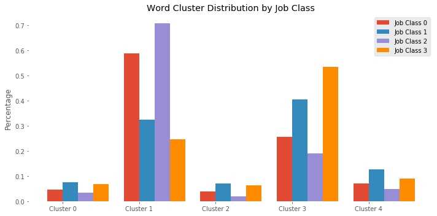

```python
labels = ["Cluster 0", 'Cluster 1', 'Cluster 2', 'Cluster 3', 'Cluster 4']

x = np.arange(len(labels))  # the label locations
width = 0.20  # the width of the bars

fig, ax = plt.subplots(figsize=(10,5))
rects1 = ax.bar(x - width/2, class_means[0], width, label='Job Class 0')
rects2 = ax.bar(x + width/2, class_means[1], width, label='Job Class 1')
rects3 = ax.bar(x + 1.5*(width), class_means[2], width, label='Job Class 2')
rects4 = ax.bar(x + 2.5*(width), class_means[3], width, label='Job Class 3',   color = 'darkorange')

# Add some text for labels, title and custom x-axis tick labels, etc.
ax.set_ylabel('Percentage')
ax.set_title('Word Cluster Distribution by Job Class')
ax.set_xticks(x)
ax.set_xticklabels(labels)
ax.legend()

ax.set_facecolor('white')

fig.tight_layout()

plt.show()
```

## Distribution of tasks per title

```python
df_word_title = df_word_job.copy()
lst_keep = ['title']
[lst_keep.append(x) for x in df_word_title.columns if "ratio" in x]
df_word_title = df_word_title[lst_keep]
df_word_title['role'] = cat_col
df_word_title.head()
```

|  | title | Cluster_0_ratio | Cluster_1_ratio | Cluster_2_ratio | Cluster_3_ratio | Cluster_4_ratio | role |
| --- | --- | --- | --- | --- | --- | --- | --- |
| 0 | Accountants | 0.117647 | 0.588235 | 0.000000 | 0.235294 | 0.058824 | Other |
| 1 | Actors | 0.157895 | 0.421053 | 0.157895 | 0.157895 | 0.105263 | Other |
| 2 | Actuaries | 0.000000 | 0.466667 | 0.066667 | 0.333333 | 0.133333 | Other |
| 3 | Acupuncturists | 0.055556 | 0.388889 | 0.111111 | 0.222222 | 0.222222 | Other |
| 4 | Acute Care Nurses | 0.000000 | 0.592593 | 0.037037 | 0.259259 | 0.111111 | Other |

```python
lst_titles = list(sorted(df_word_title['role'].unique()))
lst_ratios = []
[lst_ratios.append(x) for x in df_word_title.columns if "ratio" in x]

def cluster_ratio_title(df, lst_ratios=lst_ratios):
    return [df[x].mean() for x in lst_ratios]

title_means = [cluster_ratio(df_word_title[df_word_title["role"] == i]) for i in lst_titles]

title_means[1]
```

```
[0.024937173089831982,
 0.6386650227343794,
 0.024479646934497296,
 0.2334982846370346,
 0.07841987260425642]
```

```python
lst_titles
```

```
['Machine', 'Managers', 'Other', 'Teachers,', 'Technicians', 'Workers']
```

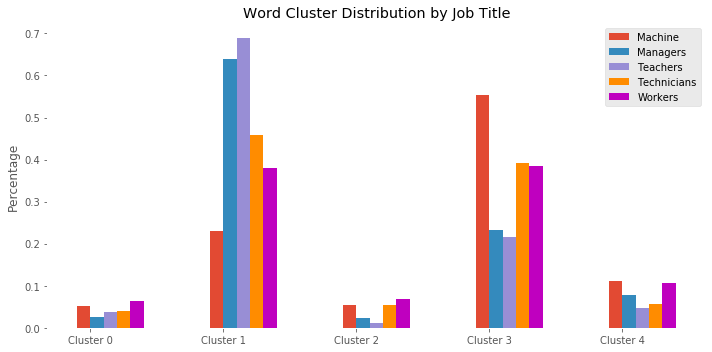

```python
labels = ["Cluster 0", 'Cluster 1', 'Cluster 2', 'Cluster 3', 'Cluster 4']

x = np.arange(len(labels))  # the label locations
width = 0.10  # the width of the bars

fig, ax = plt.subplots(figsize=(10,5))
rects1 = ax.bar(x - width/2, title_means[0], width, label='Machine')
rects2 = ax.bar(x + width/2, title_means[1], width, label='Managers')
rects3 = ax.bar(x + 1.5*(width), title_means[3], width, label='Teachers')
rects4 = ax.bar(x + 2.5*(width), title_means[4], width, label='Technicians',   color = 'darkorange')
rects5 = ax.bar(x + 3.5*(width), title_means[5], width, label='Workers',   color = 'm')


# Add some text for labels, title and custom x-axis tick labels, etc.
ax.set_ylabel('Percentage')
ax.set_title('Word Cluster Distribution by Job Title')
ax.set_xticks(x)
ax.set_xticklabels(labels)
ax.legend()

ax.set_facecolor('white')

fig.tight_layout()

plt.show()
```

### We observe that Managers and Teachers have a high proportion of tasks in the “Develop” Cluster and a low proportion in the “Report” Cluster. These are the jobs which are least likely to be automated according to the McKinsey report

## 7. Final Results

```python
df[['kmeans_word','Automated']].to_csv('final_cluster_results.csv',index=True)
```

## 8. Reformat Graphs for Presentation

```python
#Represent 4: Managerial Tasks
#Report 3: Repetitive Tasks
#Develop 1: Logical Reasoning Tasks
#Portray 2 and Appraise 0 : undefined
#dk.rename(columns = {0:"Undefined Tasks", 1:"Logical Reasoning Tasks", 2: "Undefined Tasks", 3: "Repetitive Tasks" , 4:"Managerial Tasks"}, inplace = True)
#dk[:5]
```

[output not shown]

```python
'''
labels = ["Appraise Cluster", 'Report Cluster', 'Represent Cluster', 'Develop Cluster', 'Portray Cluster']

x = np.arange(len(labels))  # the label locations
width = 0.10  # the width of the bars

fig, ax = plt.subplots(figsize=(10,5))
rects1 = ax.bar(x - width/2, title_means[0], width, label='Machine')
rects2 = ax.bar(x + width/2, title_means[1], width, label='Managers')
rects3 = ax.bar(x + 1.5*(width), title_means[3], width, label='Teachers')
rects4 = ax.bar(x + 2.5*(width), title_means[4], width, label='Technicians',   color = 'darkorange')
rects5 = ax.bar(x + 3.5*(width), title_means[5], width, label='Workers',   color = 'm')


# Add some text for labels, title and custom x-axis tick labels, etc.
ax.set_ylabel('Percentage')
ax.set_title('Word Cluster Distribution by Job Title')
ax.set_xticks(x)
ax.set_xticklabels(labels)
ax.legend()

ax.set_facecolor('white')

fig.tight_layout()

plt.show()
'''
```

[output not shown]